# Lab 2- cDNA Stanford time course dataset

#### Gene Expression and Data Visualization

#### September 6th, 2025

# Lab 2:

In this lab, we are going to work with a very popular time course cDNA data set from Paul Spellman’s lab at Stanford. This microarray was designed with probes from the yeast Saccharomyces cerevisiae genome. The data set includes 3 different experiments, each with its own time course (each array is a different time point) for measuring transcript levels that are induced by various cyclins. The transcripts that respond to this stimulus are seen to be regulated at the different stages of the cell cycle. The 3 experiments differ by the method that the yeast cultures were synchronized: α factor arrest, elutriation, and arrest of a cdc15 temperature-sensitive mutant. The cdc15 time course experiment is the one that we will use in this lab to conduct some simple mathematical manipulations and plots.

The paper, “Comprehensive Identification of Cell Cycle–regulated Genes of the Yeast Saccharomyces cerevisiae by Microarray Hybridization” is available on the course website.

## Q1) Data Setup and Loading appropriate libraries

```r
# Load core library for visualization
library(ggplot2)
# Load gplots for colorpanel
library(gplots)
```

## Q2) Unzip the text file, and read into R

```r
data <- read.table("spellman.txt", header = TRUE, row.names = 1)
# Extract the first row
head(data, 1)
```

```
        cln3.1 cln3.2 clb2.2 clb2.1 alpha0 alpha7 alpha14 alpha21 alpha28
YAL001C   0.15     NA  -0.22   0.07  -0.15  -0.15   -0.21    0.17   -0.42
        alpha35 alpha42 alpha49 alpha56 alpha63 alpha70 alpha77 alpha84 alpha91
YAL001C   -0.44   -0.15    0.24    -0.1      NA    0.18    0.42   -0.25   -0.01
        alpha98 alpha105 alpha112 alpha119 cdc15_10 cdc15_30 cdc15_50 cdc15_70
YAL001C   -0.13     0.77    -0.21     0.43    -0.16     0.09    -0.23     0.03
        cdc15_80 cdc15_90 cdc15_100 cdc15_110 cdc15_120 cdc15_130 cdc15_140
YAL001C    -0.04    -0.12     -0.28     -0.44     -0.09      0.12      0.06
        cdc15_150 cdc15_160 cdc15_170 cdc15_180 cdc15_190 cdc15_200 cdc15_210
YAL001C     -0.04      0.31      0.59      0.34     -0.28     -0.09     -0.44
        cdc15_220 cdc15_230 cdc15_240 cdc15_250 cdc15_270 cdc15_290 cdc28_0
YAL001C      0.31      0.03      0.57         0      0.02     -0.26   -0.19
        cdc28_10 cdc28_20 cdc28_30 cdc28_40 cdc28_50 cdc28_60 cdc28_70 cdc28_80
YAL001C    -0.77    -0.17    -0.19     0.13    -0.36    -0.55    -0.07    -0.01
        cdc28_90 cdc28_100 cdc28_110 cdc28_120 cdc28_130 cdc28_140 cdc28_150
YAL001C     0.03      0.27      0.49      0.85      0.66     -0.24      0.03
        cdc28_160 elu0 elu30 elu60 elu90 elu120 elu150 elu180 elu210 elu240
YAL001C      0.09  0.3 -0.12  0.24  0.18  -0.24   0.11  -0.12   0.37   0.07
        elu270 elu300 elu330 elu360 elu390
YAL001C  -0.09  -0.32   0.04  -0.48   0.04
```

## Q3) Look at the dimensions of the data frame

and make sure that there are 6,178 genes and 77 arrays/sample.

```r
dim(data)
```

```
[1] 6178   77
```

## Q4) Isolate only the cdc15 experiment (samples 23-46).

```r
# Isolate the cdc15 experiment (columns 23 through 46)
cdc15 <- data[, 23:46]
head(cdc15, 1)
```

```
        cdc15_10 cdc15_30 cdc15_50 cdc15_70 cdc15_80 cdc15_90 cdc15_100
YAL001C    -0.16     0.09    -0.23     0.03    -0.04    -0.12     -0.28
        cdc15_110 cdc15_120 cdc15_130 cdc15_140 cdc15_150 cdc15_160 cdc15_170
YAL001C     -0.44     -0.09      0.12      0.06     -0.04      0.31      0.59
        cdc15_180 cdc15_190 cdc15_200 cdc15_210 cdc15_220 cdc15_230 cdc15_240
YAL001C      0.34     -0.28     -0.09     -0.44      0.31      0.03      0.57
        cdc15_250 cdc15_270 cdc15_290
YAL001C         0      0.02     -0.26
```

## Q5) Now calculate a correlation matrix between the time points (use Pearson’s correlation).

Make sure to title the plot, label the axes, and provide a legend of the color gradient. In the correlation calculation, make sure to use the argument ‘use’ and value=pairwise.complete.obs since all of these arrays have at least one missing value.

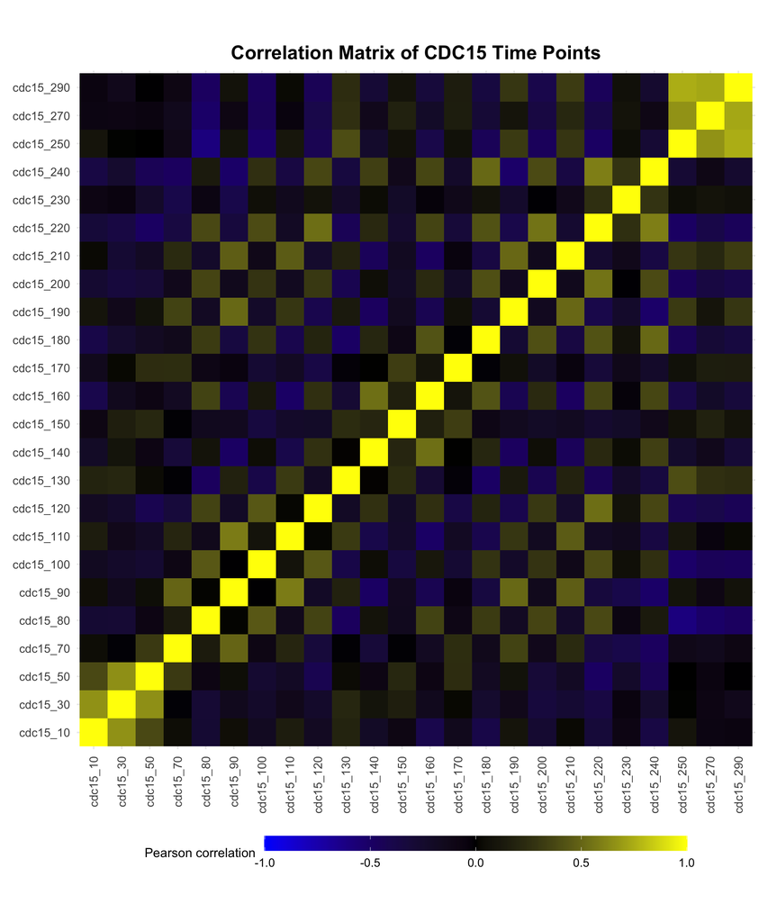

```r
## Q5) Correlation matrix
# 1) Correlation
cdc15_cor <- cor(cdc15, use = "pairwise.complete.obs", method = "pearson")

# 2) Tidy the matrix for ggplot (keep original ordering)
df <- as.data.frame(as.table(cdc15_cor))
names(df) <- c("y","x","r")
df$x <- factor(df$x, levels = colnames(cdc15_cor))
df$y <- factor(df$y, levels = rownames(cdc15_cor))

# 3) Heatmap with legend at bottom; colors: blue (low) → black (mid) → yellow (high)
ggplot(df, aes(x = x, y = y, fill = r)) +
  geom_tile() +
  coord_fixed() +                       # square cells
  scale_fill_gradient2(
    low = "blue", mid = "black", high = "yellow",
    midpoint = 0, limits = c(-1, 1), name = "Pearson correlation"
  ) +
  labs(
    title = "Correlation Matrix of CDC15 Time Points",
    x = NULL, y = NULL
  ) +
  theme_minimal(base_size = 14) +
  theme(
    legend.position = "bottom",
    legend.direction = "horizontal",
    # Make the legend a compact color bar
    legend.title = element_text(size = 12, margin = margin(r = 8)),
    legend.text  = element_text(size = 11),
    axis.text.x  = element_text(angle = 90, vjust = 0.5, hjust = 1, size = 11),
    axis.text.y  = element_text(size = 11),
    plot.title   = element_text(size = 18, face = "bold", hjust = 0.5),
    plot.margin  = margin(t = 10, r = 12, b = 10, l = 12)
  ) +
  guides(fill = guide_colorbar(
    barwidth = unit(14, "cm"),   # adjust to taste
    barheight = unit(0.5, "cm"),
    ticks = TRUE
  ))
```

## Q6) Select the gene YAL002W

which is VPS8, a membrane-binding component of the CORVET complex; involved in endosomal vesicle tethering and fusion in the endosome to vacuole protein targeting pathway. Impute the missing values with the row mean (save as something). Make sure to cast the gene to numeric.

```r
## Q6) imputing missing VPS8 values with the mean
vps8 <- cdc15["YAL002W", ]
vps8 <- as.numeric(vps8)

# Which positions are NA?
which_na <- names(cdc15)[is.na(vps8)]
print(which_na)  # expect: cdc15_10, cdc15_30, cdc15_50, cdc15_190, cdc15_270, cdc15_290
```

```
[1] "cdc15_10"  "cdc15_30"  "cdc15_50"  "cdc15_190" "cdc15_270" "cdc15_290"
```

```r
# Row mean (NA-ignored)
vps8_mean <- mean(vps8, na.rm = TRUE)
print(vps8_mean) # ~ 0
```

```
[1] 1.233581e-17
```

```r
#pre-Impute dataset
cdc15["YAL002W", ]
```

```
        cdc15_10 cdc15_30 cdc15_50 cdc15_70 cdc15_80 cdc15_90 cdc15_100
YAL002W       NA       NA       NA    -0.58     0.23    -0.23      0.08
        cdc15_110 cdc15_120 cdc15_130 cdc15_140 cdc15_150 cdc15_160 cdc15_170
YAL002W     -0.62      0.55     -0.32      0.03     -0.56      0.47     -0.15
        cdc15_180 cdc15_190 cdc15_200 cdc15_210 cdc15_220 cdc15_230 cdc15_240
YAL002W      0.49        NA      0.23     -0.49      0.33      0.18      0.65
        cdc15_250 cdc15_270 cdc15_290
YAL002W     -0.29        NA        NA
```

```r
# Impute
vps8_imputed <- ifelse(is.na(vps8), vps8_mean, vps8)
stopifnot(!any(is.na(vps8_imputed)))
names(vps8_imputed) <- colnames(cdc15)  # keep labels for Q7

# Check result
vps8_imputed
```

```
     cdc15_10      cdc15_30      cdc15_50      cdc15_70      cdc15_80
 1.233581e-17  1.233581e-17  1.233581e-17 -5.800000e-01  2.300000e-01
     cdc15_90     cdc15_100     cdc15_110     cdc15_120     cdc15_130
-2.300000e-01  8.000000e-02 -6.200000e-01  5.500000e-01 -3.200000e-01
    cdc15_140     cdc15_150     cdc15_160     cdc15_170     cdc15_180
 3.000000e-02 -5.600000e-01  4.700000e-01 -1.500000e-01  4.900000e-01
    cdc15_190     cdc15_200     cdc15_210     cdc15_220     cdc15_230
 1.233581e-17  2.300000e-01 -4.900000e-01  3.300000e-01  1.800000e-01
    cdc15_240     cdc15_250     cdc15_270     cdc15_290
 6.500000e-01 -2.900000e-01  1.233581e-17  1.233581e-17
```

## Q7) Generate a profile plot of the same gene

Title the plot, label the axes, and on the x-axis, provide the time points only for each array (no “cdc15_” prefix) so we can visualize the transcript pattern over time. Use lwd in the plot command (lwd=line width).

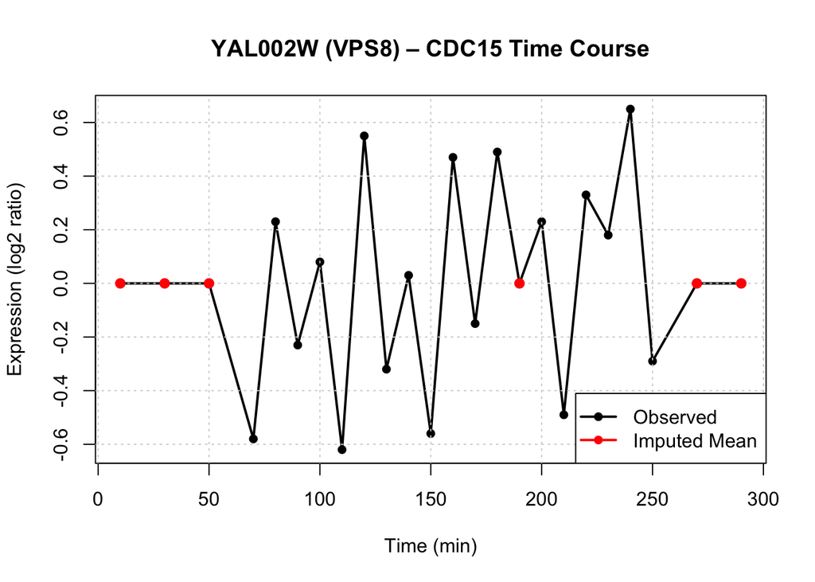

```r
## Q7) Profile plot for YAL002W (VPS8) across CDC15 time points
tp <- as.numeric(gsub("^cdc15_", "", names(vps8_imputed)))

# Order values by time
o <- order(tp)
tp <- tp[o]
vps8_plot <- vps8_imputed[o]

# Identify which time points were imputed
na_idx <- names(vps8_imputed) %in% c("cdc15_10","cdc15_30","cdc15_50",
                                     "cdc15_190","cdc15_270","cdc15_290")
na_idx <- na_idx[o]  # reorder to match tp order

# Plot the full profile line
plot(tp, vps8_plot,
     type = "o", lwd = 2, pch = 16, col = "black",
     xlab = "Time (min)",
     ylab = "Expression (log2 ratio)",
     main = "YAL002W (VPS8) – CDC15 Time Course")

grid()

# Overlay imputed points in blue
points(tp[na_idx], vps8_plot[na_idx], col = "red", pch = 16, cex = 1.2)

# Add legend
legend("bottomright",
       legend = c("Observed", "Imputed Mean"),
       col = c("black", "red"), pch = 16, lwd = 2)
```

## Q8) Now let’s create a simple shiny app which allows the user to select and correlate any time point verse another time point across all genes.

Now let’s create a simple shiny app which allows the user to select and correlate any time point verse another time point across all genes.

```r
############################################################
# Dylan Renard
# JHU Gene Expression Lab 2
# September 6th 2025
# Professor Brandon Higgs
#
# CDC15 Time Course Shiny App (Q8 on Lab 2)
#
# Description:
#   This application visualizes Spellman’s yeast cell cycle dataset
#   (CDC15 temperature-sensitive mutant arrest experiment).
#
# Features:
#   - Reads in spellman.txt and subsets the CDC15 arrays (23–46)
#   - Launches a Shiny web app with interactive controls:
#       * X Variable selector: pick any CDC15 time point
#       * Y Variable selector: pick any CDC15 time point
#       * Point Color selector: customize scatterplot aesthetics
#   - Generates scatter plots across all 6,178 yeast genes
#   - Drops missing values automatically (pairwise complete obs)
#
# Notes:
#   - Based on the Lecture 3 "iris dataset" Shiny demo,
#     but swaps iris columns for CDC15 experiment arrays
#   - Designed for exploratory correlation visualization
#   - No correlation statistics or p-values displayed
#
# Usage:
#   - Save this file as app.R in the same directory as spellman.txt
#   - Run in RStudio: click "Run App" OR use:
#         shiny::runApp("shinyApp.R")
#
# Source Data:
#   Spellman PT, et al. (1998). Comprehensive identification of
#   cell cycle–regulated genes of the yeast Saccharomyces cerevisiae
#   by microarray hybridization. Mol Biol Cell. 9:3273–3297.
############################################################


# ---- Load CDC15 data ----
# Assumes spellman.txt is in your working directory
spell <- read.table("spellman.txt",
                    header = TRUE, row.names = 1, check.names = FALSE,
                    sep = "", stringsAsFactors = FALSE)

# CDC15 experiment: arrays 23–46
dat <- as.matrix(spell[, 23:46])
storage.mode(dat) <- "double"

library(shiny)
# ---- UI ----
ui <- fluidPage(
  titlePanel("CDC15: Time Point vs Time Point"),
  sidebarLayout(
    sidebarPanel(
      selectInput('xcol',
                  'X Variable',
                  dimnames(dat)[[2]],
                  selected = dimnames(dat)[[2]][1]),
      selectInput('ycol',
                  'Y Variable',
                  dimnames(dat)[[2]], selected = dimnames(dat)[[2]][2]),
      selectInput('ptcol', 'Point color',
                  choices = c("red", "blue", "black", "darkgreen", "orange"),
                  selected = "red")
    ),
    mainPanel(
      plotOutput('plot', height = "520px")
    )
  )
)

# ---- Server ----
server <- function(input, output) {

  selectedData <- reactive({
    d <- dat[, c(input$xcol, input$ycol), drop = FALSE]
    keep <- complete.cases(d[,1], d[,2])
    data.frame(x = as.numeric(d[keep, 1]),
               y = as.numeric(d[keep, 2]))
  })

  output$plot <- renderPlot({
    d <- selectedData()
    plot(d$x, d$y,
         pch = 16, cex = 0.6, col = input$ptcol,
         xlab = input$xcol, ylab = input$ycol,
         main = "All Genes: Time Point vs. Time Point")
    grid()
  })
}

# ---- Launch ----
# shinyApp(ui = ui, server = server)
```

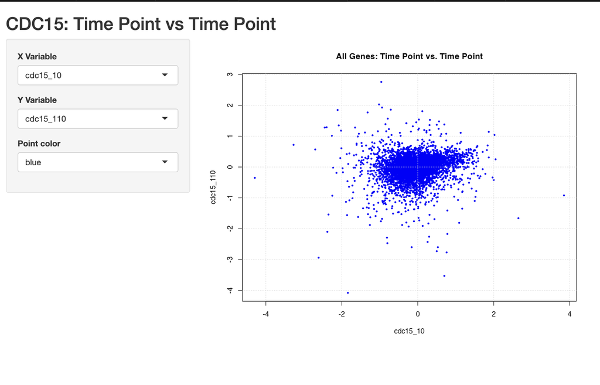

## Sources:

Chang W, Cheng J, Allaire J, Sievert C, Schloerke B, Xie Y, Allen J, McPherson J, Dipert A, Borges B (2025). *shiny: Web Application Framework for R*. R package version 1.11.1, https://CRAN.R-project.org/package=shiny.

H. Wickham. ggplot2: Elegant Graphics for Data Analysis. Springer-Verlag New York, 2016.

R Core Team (2025). R: A language and environment for statistical computing. R Foundation for Statistical Computing, Vienna, Austria. https://www.R-project.org/.

Spellman, P. T., Sherlock, G., Zhang, M. Q., Iyer, V. R., Anders, K., Eisen, M. B., Brown, P. O., Botstein, D., & Futcher, B. (1998). Comprehensive identification of cell cycle-regulated genes of the yeast Saccharomyces cerevisiae by microarray hybridization. Molecular biology of the cell, 9(12), 3273–3297. https://doi.org/10.1091/mbc.9.12.3273